# STA 141B Final Project

**Group Members:**

Isabelle Berkowitz, Vinay Singal, Keon Sadeghi, Carly Schwartzberg, Aryan Punjani

# Project Outline

The following serves as a guide to make our final project easy to follow along, including an outline of how we structed our project

1. **Introduction**
2. **Graphs and Visualizations**
3. **NLP Analysis for Stock Market news from CNBC**
4. **API key for Unemployment rates throughout Covid-19 Pandemic**
5. **Conclusion**

```python
#setting up our workign enviornment
!pip install yfinance
!pip install pandas
!pip install matplotlib.pyplot


import yfinance as yf
import pandas as pd
import plotly.graph_objs as go
import matplotlib.pyplot as plt
import numpy as np
import requests
import nltk
from nltk.corpus import stopwords
from nltk.tokenize import word_tokenize
from nltk.probability import FreqDist
from bs4 import BeautifulSoup
import string
```

[output not shown]

# Part 1: Introdcution

**1A. Purpose**

The stock market is a dynamic system for several different exchanges within our economy in which shares of companies are bought and sold. It allows investors and businesses to earn more profit and grow their companies. The figure below explains how the stock market operates in the cycle in two ways 1) through trading their stocks into the market and 2) through company profits which are dependent on a value that is determined on how well the company is performing and the market demand for their goods. There are multiple factors that influence the value of the shares such as how our economy is fluctuating, the blow-up of company products, and trends within the industry. The Dow Jones Industrial Average(DJIA) is a well-known stock market index which tracks 30 large ‘publicly-owned blue-chip companies trading on the New York Stock Exchange (NYSE) and Nasdaq.’ Our main goal is to help mitigate stock market volatility and fluctuation during shocks in the country. We hypothesize that the stock market bounced back strong from the Covid-19 pandemic so with that premise, when shocks occur in the country there should not be as much volatility in the market since we know that after one of the biggest economic turmoils of the 2000s the market bounced back strong.Our key question we are aiming to answer is how the stock market, specifically the trend and values of Dow Jones Industrial in pre covid (2018), peak-covid(2020), and during the 2022 recession was affected.

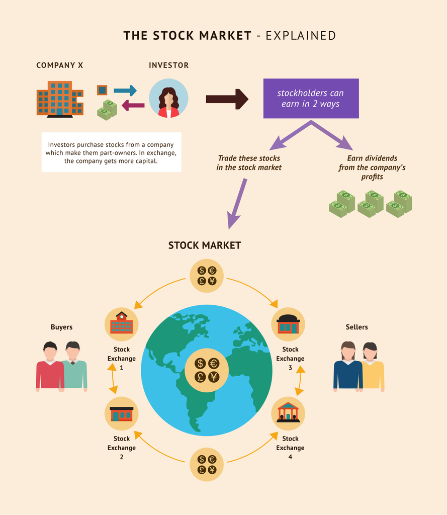

**1B. Overview of Data Manipulation**

The data set we used from Yahoo Finance contained the Dow Jones stock data from 1962 to the present. However, for this project, we wanted to focus on the effects of covid-19 on the stock market, which means we wanted to look at specific years. In order to isolate these years, we extracted a specific time period from the Yahoo Finance data. We set the start date to January 1st, 2018, and the end date to December 31st, 2022. In order to examine the effects of covid-19, we chose 2018 as our pre-covid data, 2020 as our data for the peak of the pandemic (this was the year the stock market was most affected), and 2022 as our post-covid data. While covid-19 was still present in 2022, it had begun to subside, and many businesses had recovered by this time. Since we extracted the time period 2018-2022, we wanted to narrow our focus even more, therefore we removed 2019 and 2021 from our dataset.

The years 2019 and 2021 marked significant turning points. In late 2019 covid-19 had just begun, therefore the overall data of that year would not be a suitable representation of a mid-covid year which is what we were looking for in our analysis. The covid-19 pandemic still impacted the U.S. in early 2021, making this year infeasible for post-covid representation. Therefore in order to accurately capture the effects of the pandemic during mid-covid and post-covid we chose 2020 and 2022 rather than 2019 and 2021. 2018 provided us a good baseline for pre-covid, 2020 had the best representation of the peak of the pandemic, and 2022 offered the most accurate representation of post-covid recovery. By choosing these specific years, we were able to attain the most accurate view of the effects covid-19 had on the stock market. We then calculated averages by using the highs and lows columns of the data set, and added an "averages" column to our dataset. This displayed the average stock price for each company for every day throughout the dataset. This additional data allowed us to gain a better understanding of the effects that covid-19 had on the stock market during 2018, 2020, and 2022.

By manipulating and refining our data set in this way, we were able to acquire all the information necessary for our project while removing all irrelevant data. The resulting dataset is an accurate representation of the stock market during pre-covid, mid-covid, and post-covid, and provided us with useful insights for our analysis.

**1C. Summary and Explanation of Data Collection**

```python
#Defined the start date and end date of the data.
startDate = '2018-01-01'
endDate = '2022-12-31'

#Defines the list of Dow Jones Industrial Average (DJIA) tickers.
names = ['AAPL', 'AMGN', 'AXP', 'BA', 'CAT', 'CRM', 'CSCO', 'CVX', 'DIS', 'DOW', 'GS', 'HD', 'HON', 'IBM', 'INTC', 'JNJ', 'JPM', 'KO', 'MCD', 'MMM', 'MRK', 'MSFT', 'NKE', 'PG', 'TRV', 'UNH', 'V', 'VZ', 'WBA', 'WMT']

#Gets the data for the DJIA stocks using the start and end dates we selected
data = {t: yf.download(t, start=startDate, end=endDate) for t in names}

#Combines the data in DJIA into a single dataset.
data2 = yf.download(names, start=startDate, end=endDate, group_by='t')

#Removes the data from 2019 and 2021 using != operator
data2 = data2[data2.index.year != 2019]
data2 = data2[data2.index.year != 2021]

#Uses a for loop to calculate the high/low average for every company in DJIA.
for company in data2.columns.levels[0]:
    data2[company, 'Average'] = (data2[company, 'High'] + data2[company, 'Low']) / 2

#Sorts the columns alphabetically, sets axis=1 to perform a column-wise operation..
data2 = data2.sort_index(axis=1)

#Prints the DataFrame.
data2
```

[output not shown]

| Date | AAPL Adj Close | AAPL Average | AAPL Close | AAPL High | AAPL Low | AAPL Open | AAPL Volume | AMGN Adj Close | AMGN Average | AMGN Close | ... | WBA Low | WBA Open | WBA Volume | WMT Adj Close | WMT Average | WMT Close | WMT High | WMT Low | WMT Open | WMT Volume |
| --- | --- | --- | --- | --- | --- | --- | --- | --- | --- | --- | --- | --- | --- | --- | --- | --- | --- | --- | --- | --- | --- |
| 2018-01-02 | 40.888062 | 42.695000 | 43.064999 | 43.075001 | 42.314999 | 42.540001 | 102223600 | 151.353928 | 176.120003 | 177.000000 | ... | 72.970001 | 73.279999 | 6605000 | 89.607697 | 99.154999 | 98.589996 | 99.790001 | 98.519997 | 99.300003 | 10150500 |
| 2018-01-03 | 40.880951 | 43.313751 | 43.057499 | 43.637501 | 42.990002 | 43.132500 | 118071600 | 154.209991 | 178.599998 | 180.339996 | ... | 74.309998 | 75.089996 | 7147300 | 90.389374 | 99.384998 | 99.449997 | 100.000000 | 98.769997 | 98.849998 | 8903600 |
| 2018-01-04 | 41.070839 | 43.193750 | 43.257500 | 43.367500 | 43.020000 | 43.134998 | 89738400 | 153.560104 | 179.805000 | 179.580002 | ... | 70.730003 | 73.489998 | 12456000 | 90.471161 | 99.345001 | 99.540001 | 99.779999 | 98.910004 | 99.540001 | 6830400 |
| 2018-01-05 | 41.538441 | 43.552500 | 43.750000 | 43.842499 | 43.262501 | 43.360001 | 94640000 | 154.475052 | 179.955002 | 180.649994 | ... | 71.820000 | 71.900002 | 9067200 | 91.007423 | 99.994999 | 100.129997 | 100.379997 | 99.610001 | 99.639999 | 7284000 |
| 2018-01-08 | 41.384155 | 43.692499 | 43.587502 | 43.902500 | 43.482498 | 43.587502 | 82271200 | 154.432327 | 179.839996 | 180.600006 | ... | 72.750000 | 73.150002 | 5312500 | 92.352585 | 100.980000 | 101.610001 | 101.750000 | 100.209999 | 100.250000 | 8843900 |
| ... | ... | ... | ... | ... | ... | ... | ... | ... | ... | ... | ... | ... | ... | ... | ... | ... | ... | ... | ... | ... | ... |
| 2022-12-23 | 131.658981 | 131.029999 | 131.860001 | 132.419998 | 129.639999 | 130.919998 | 63814900 | 261.612915 | 264.095001 | 263.920013 | ... | 38.209999 | 38.560001 | 3476700 | 143.183151 | 143.040001 | 143.770004 | 143.800003 | 142.279999 | 143.050003 | 3182500 |
| 2022-12-27 | 129.831772 | 130.065002 | 130.029999 | 131.410004 | 128.720001 | 131.380005 | 69007800 | 261.087555 | 264.744995 | 263.390015 | ... | 38.110001 | 38.619999 | 3940100 | 143.222977 | 143.820000 | 143.809998 | 144.449997 | 143.190002 | 144.039993 | 3348200 |
| 2022-12-28 | 125.847855 | 128.450001 | 126.040001 | 131.029999 | 125.870003 | 129.669998 | 85438400 | 259.134766 | 263.380005 | 261.420013 | ... | 37.560001 | 38.250000 | 4008900 | 140.713257 | 142.290001 | 141.289993 | 143.669998 | 140.910004 | 143.470001 | 5082100 |
| 2022-12-29 | 129.412415 | 129.105000 | 129.610001 | 130.479996 | 127.730003 | 127.989998 | 75703700 | 260.859558 | 263.510010 | 263.160004 | ... | 37.360001 | 37.660000 | 5251500 | 141.569748 | 142.385002 | 142.149994 | 143.020004 | 141.750000 | 142.139999 | 3057300 |
| 2022-12-30 | 129.731918 | 128.689999 | 129.929993 | 129.949997 | 127.430000 | 128.410004 | 77034200 | 260.344086 | 261.370010 | 262.640015 | ... | 36.970001 | 37.240002 | 5406200 | 141.211227 | 141.400002 | 141.789993 | 141.990005 | 140.809998 | 141.559998 | 3835300 |

755 rows × 210 columns

```python
#Since the data originally started in 1962 we wanted to isolate a certain section of time to analyze in order to look at the impact of covid
#Here we are isolating 2018 specifically to look at a pre covid year, we are setting the start date as January 1st 2018 and the end date as December 31 2018

startOne = '2018-01-01'
endOne = '2018-12-31'

#Now we download the yahoo finance library in order to extract the data
#We use startOne and endOne in order to create a table for 2018 data

start_data = yf.download('^DJI', start=startOne, end=endOne)

#Here we are isolating 2020 specifically to look at a year in the middle of peak covid, we are setting the start date as January 1st 2020 and the end date as December 31 2020

startTwo = '2020-01-01'
endTwo = '2020-12-31'

#We use startTwo and endTwo in order to create a table for 2020 data

mid_data = yf.download('^DJI', start=startTwo, end=endTwo)

#Here we are isolating 2022 specifically to look at a post covid year, we are setting the start date as January 1st 2022 and the end date as December 31 2022

startThree = '2022-01-01'
endThree = '2022-12-31'

#We use startThree and endThree in order to create a table for 2022 data

end_data = yf.download('^DJI', start=startThree, end=endThree)
```

```
[*********************100%***********************]  1 of 1 completed
[*********************100%***********************]  1 of 1 completed
[*********************100%***********************]  1 of 1 completed
```

```python
# Displaying the Dow Jones market prices every working day from the year 2018

start_data
```

| Date | Open | High | Low | Close | Adj Close | Volume |
| --- | --- | --- | --- | --- | --- | --- |
| 2018-01-02 | 24809.349609 | 24864.189453 | 24741.699219 | 24824.009766 | 24824.009766 | 341130000 |
| 2018-01-03 | 24850.449219 | 24941.919922 | 24825.550781 | 24922.679688 | 24922.679688 | 456790000 |
| 2018-01-04 | 24964.859375 | 25105.960938 | 24963.269531 | 25075.130859 | 25075.130859 | 403280000 |
| 2018-01-05 | 25114.919922 | 25299.789062 | 25112.009766 | 25295.869141 | 25295.869141 | 358020000 |
| 2018-01-08 | 25308.400391 | 25311.990234 | 25235.410156 | 25283.000000 | 25283.000000 | 341390000 |
| ... | ... | ... | ... | ... | ... | ... |
| 2018-12-21 | 22871.740234 | 23254.589844 | 22396.339844 | 22445.369141 | 22445.369141 | 900510000 |
| 2018-12-24 | 22317.279297 | 22339.869141 | 21792.199219 | 21792.199219 | 21792.199219 | 308420000 |
| 2018-12-26 | 21857.730469 | 22878.919922 | 21712.529297 | 22878.449219 | 22878.449219 | 433080000 |
| 2018-12-27 | 22629.060547 | 23138.890625 | 22267.419922 | 23138.820312 | 23138.820312 | 407940000 |
| 2018-12-28 | 23213.609375 | 23381.880859 | 22981.330078 | 23062.400391 | 23062.400391 | 336510000 |

250 rows × 6 columns

```python
# Displaying the Dow Jones market prices every working day from the year 2020

mid_data
```

| Date | Open | High | Low | Close | Adj Close | Volume |
| --- | --- | --- | --- | --- | --- | --- |
| 2020-01-02 | 28638.970703 | 28872.800781 | 28627.769531 | 28868.800781 | 28868.800781 | 251820000 |
| 2020-01-03 | 28553.330078 | 28716.310547 | 28500.359375 | 28634.880859 | 28634.880859 | 239590000 |
| 2020-01-06 | 28465.500000 | 28708.019531 | 28418.630859 | 28703.380859 | 28703.380859 | 252760000 |
| 2020-01-07 | 28639.179688 | 28685.500000 | 28565.279297 | 28583.679688 | 28583.679688 | 258900000 |
| 2020-01-08 | 28556.140625 | 28866.179688 | 28522.509766 | 28745.089844 | 28745.089844 | 291750000 |
| ... | ... | ... | ... | ... | ... | ... |
| 2020-12-23 | 30046.730469 | 30292.529297 | 30046.730469 | 30129.830078 | 30129.830078 | 274050000 |
| 2020-12-24 | 30155.919922 | 30209.669922 | 30099.300781 | 30199.869141 | 30199.869141 | 145570000 |
| 2020-12-28 | 30283.230469 | 30525.560547 | 30283.230469 | 30403.970703 | 30403.970703 | 302490000 |
| 2020-12-29 | 30492.070312 | 30588.789062 | 30274.240234 | 30335.669922 | 30335.669922 | 357610000 |
| 2020-12-30 | 30415.089844 | 30525.349609 | 30393.039062 | 30409.560547 | 30409.560547 | 291890000 |

252 rows × 6 columns

```python
# Displaying the Dow Jones market prices every working day from the year 2022.

end_data
```

| Date | Open | High | Low | Close | Adj Close | Volume |
| --- | --- | --- | --- | --- | --- | --- |
| 2022-01-03 | 36321.589844 | 36595.820312 | 36246.449219 | 36585.058594 | 36585.058594 | 347930000 |
| 2022-01-04 | 36636.000000 | 36934.839844 | 36636.000000 | 36799.648438 | 36799.648438 | 435080000 |
| 2022-01-05 | 36722.601562 | 36952.648438 | 36400.390625 | 36407.109375 | 36407.109375 | 462040000 |
| 2022-01-06 | 36409.050781 | 36464.191406 | 36200.679688 | 36236.468750 | 36236.468750 | 385890000 |
| 2022-01-07 | 36249.589844 | 36382.839844 | 36111.531250 | 36231.660156 | 36231.660156 | 356110000 |
| ... | ... | ... | ... | ... | ... | ... |
| 2022-12-23 | 32961.058594 | 33226.140625 | 32814.019531 | 33203.929688 | 33203.929688 | 221050000 |
| 2022-12-27 | 33224.230469 | 33387.718750 | 33069.578125 | 33241.558594 | 33241.558594 | 246010000 |
| 2022-12-28 | 33264.761719 | 33379.550781 | 32869.148438 | 32875.710938 | 32875.710938 | 252260000 |
| 2022-12-29 | 33021.429688 | 33293.421875 | 33020.351562 | 33220.800781 | 33220.800781 | 243060000 |
| 2022-12-30 | 33121.609375 | 33152.550781 | 32847.820312 | 33147.250000 | 33147.250000 | 295500000 |

251 rows × 6 columns

```python
# We now are displaying the highs, lows, and average stock price for each company in the Dow Jones Industrial per day.
```

```python
highs = data2.loc[:, (slice(None), 'High')]
lows = data2.loc[:, (slice(None), 'Low')]
averages = data2.loc[:, (slice(None), 'Average')]
result = pd.concat([highs, lows, averages], axis = 1)
result
```

| Date | AAPL High | AMGN High | AXP High | BA High | CAT High | CRM High | CSCO High | CVX High | DIS High | DOW High | ... | MRK Average | MSFT Average | NKE Average | PG Average | TRV Average | UNH Average | V Average | VZ Average | WBA Average | WMT Average |
| --- | --- | --- | --- | --- | --- | --- | --- | --- | --- | --- | --- | --- | --- | --- | --- | --- | --- | --- | --- | --- | --- |
| 2018-01-02 | 43.075001 | 177.820007 | 99.730003 | 296.989990 | 159.389999 | 104.699997 | 38.950001 | 127.739998 | 111.809998 | NaN | ... | 53.816793 | 85.904999 | 63.170000 | 91.240002 | 133.880005 | 221.224998 | 114.514999 | 53.184999 | 74.080002 | 99.154999 |
| 2018-01-03 | 43.637501 | 181.440002 | 99.760002 | 298.500000 | 157.490005 | 106.139999 | 39.279999 | 128.940002 | 113.190002 | NaN | ... | 53.540075 | 86.240002 | 63.209999 | 90.804996 | 132.110001 | 222.165001 | 115.225002 | 52.760000 | 75.055000 | 99.384998 |
| 2018-01-04 | 43.367500 | 180.860001 | 101.650002 | 298.420013 | 159.580002 | 107.660004 | 39.540001 | 128.350006 | 113.000000 | NaN | ... | 54.293894 | 87.115002 | 63.049999 | 91.189999 | 133.055000 | 225.135002 | 116.695000 | 52.360001 | 72.115002 | 99.345001 |
| 2018-01-05 | 43.842499 | 180.880005 | 101.080002 | 308.890015 | 162.050003 | 108.300003 | 39.880001 | 128.100006 | 112.680000 | NaN | ... | 54.379772 | 87.920002 | 63.885002 | 90.935001 | 131.974998 | 226.885002 | 117.709999 | 52.615000 | 72.535000 | 99.994999 |
| 2018-01-08 | 43.902500 | 181.250000 | 101.199997 | 310.859985 | 166.429993 | 109.139999 | 39.959999 | 128.630005 | 111.279999 | NaN | ... | 54.270039 | 88.090000 | 64.344999 | 91.349998 | 131.750000 | 226.660004 | 119.275002 | 52.395000 | 73.375000 | 100.980000 |
| ... | ... | ... | ... | ... | ... | ... | ... | ... | ... | ... | ... | ... | ... | ... | ... | ... | ... | ... | ... | ... | ... |
| 2022-12-23 | 132.419998 | 265.290009 | 147.139999 | 189.429993 | 240.539993 | 129.860001 | 47.490002 | 177.580002 | 88.070000 | 50.910999 | ... | 111.500000 | 236.404999 | 116.474998 | 152.294998 | 188.389999 | 527.105011 | 204.880005 | 38.230000 | 38.484999 | 143.040001 |
| 2022-12-27 | 131.410004 | 266.609985 | 147.860001 | 192.440002 | 245.050003 | 131.750000 | 47.709999 | 180.229996 | 87.940002 | 51.220001 | ... | 112.059998 | 237.379997 | 117.009998 | 153.490005 | 190.059998 | 532.845001 | 205.740005 | 38.860001 | 38.395000 | 143.820000 |
| 2022-12-28 | 131.029999 | 265.619995 | 146.820007 | 191.320007 | 243.820007 | 131.139999 | 47.770000 | 179.300003 | 86.690002 | 51.349998 | ... | 111.974998 | 236.945000 | 116.599998 | 153.274994 | 189.665001 | 532.940002 | 206.665001 | 39.125000 | 38.065001 | 142.290001 |
| 2022-12-29 | 130.479996 | 264.880005 | 147.619995 | 190.250000 | 241.610001 | 132.949997 | 47.740002 | 179.199997 | 88.239998 | 50.801998 | ... | 111.224998 | 238.784996 | 116.935001 | 152.690002 | 189.000000 | 531.269989 | 207.014999 | 39.170000 | 37.665001 | 142.385002 |
| 2022-12-30 | 129.949997 | 263.230011 | 147.929993 | 190.649994 | 240.160004 | 132.639999 | 47.669998 | 179.949997 | 87.120003 | 50.530998 | ... | 110.770000 | 238.310005 | 116.509998 | 151.559998 | 187.915001 | 527.670013 | 206.869995 | 39.379999 | 37.175001 | 141.400002 |

755 rows × 90 columns

# Part 2: Graphs and Visualizations

**2A. Line plots for the closing prices for Pre-Covid , Peak-Covid, and Post-Covid**

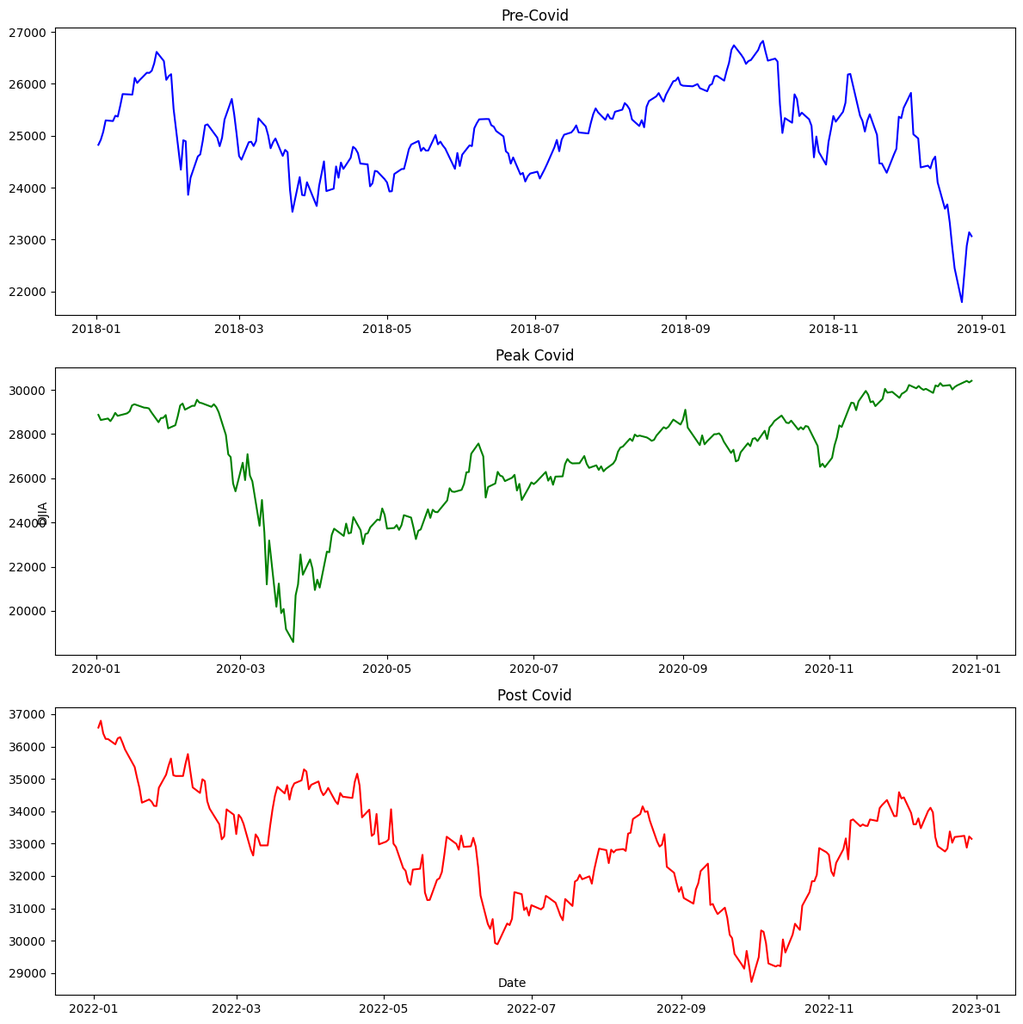

```python
fig, axes = plt.subplots(nrows = 3, ncols = 1, figsize = (12, 12))
# Plot pre-COVID data
axes[0].plot(start_data['Close'], color = 'blue')
axes[0].set_title('Pre-Covid')

# Plot mid-COVID data
axes[1].plot(mid_data['Close'], color = 'green')
axes[1].set_title('Peak Covid')

# Plot current data
axes[2].plot(end_data['Close'], color = 'red')
axes[2].set_title('Post Covid')


fig.text(0.5, 0.04, 'Date', ha = 'center')
fig.text(0.04, 0.5, 'DJIA', va = 'center', rotation = 'vertical')

plt.tight_layout()
plt.show()
```

**2B. Combined line plots for the closing prices for Pre-Covid , Peak-Covid, and Post-Covid**

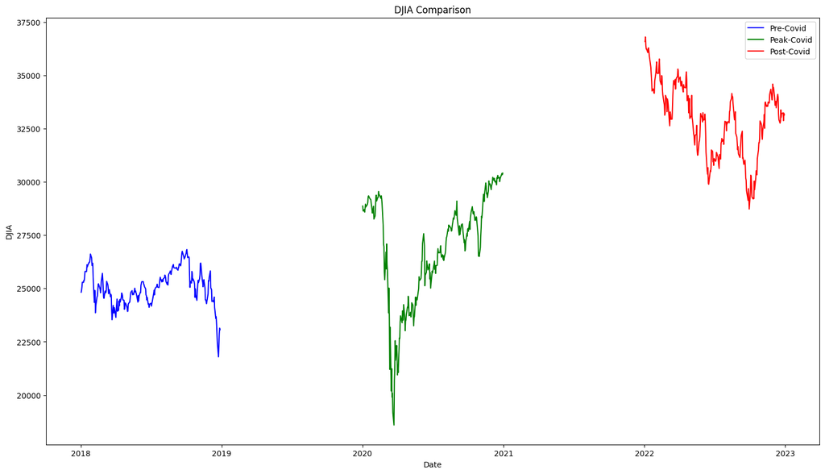

```python
plt.figure(figsize = (18,10))

plt.plot(start_data["Close"], label = 'Pre-Covid', color='blue')

# Plot the second DJIA dataset in green color
plt.plot(mid_data["Close"], label = 'Peak-Covid', color='green')

# Plot the third DJIA dataset in red color
plt.plot(end_data["Close"], label = 'Post-Covid', color='red')


plt.xlabel('Date')
plt.ylabel('DJIA')
plt.title('DJIA Comparison')
plt.legend()
plt.show()
```

**2C. Comparing closing prices for the top 3 indicies in the stock market**

```python
#Here we are looking at the data from yahoo finance, grabbing data from djia, sp500, and nasdaq between 2018 and 2022
djia = yf.download('^DJI', start = startDate, end = endDate)
sp500 = yf.download('^GSPC', start = startDate, end = endDate)
nasdaq = yf.download('^IXIC', start = startDate, end = endDate)

#We are looking at the close columns for each stock in order to retrieve the closing prices
#We select the column which contains the adjusted closing prices of the Dow Jones, S&P 500, and NASDAQ indices from the djia dataframe
#Then we are grouping the data by year by using the '.resample()' method and return the values necessary with the '.last()' function
#Then we are simply finding the percent change of each index using '.pct_change()'
djiaNew = djia['Adj Close'].resample('Y').last().pct_change()
sp500New = sp500['Adj Close'].resample('Y').last().pct_change()
nasdaqNew = nasdaq['Adj Close'].resample('Y').last().pct_change()
```

```
[*********************100%***********************]  1 of 1 completed
[*********************100%***********************]  1 of 1 completed
[*********************100%***********************]  1 of 1 completed
```

The Covid-19 pandemic had a profound impact on the global economy, affecting every sector and industry. In the United States, the stock market was not immune to this impact, with the Dow Jones Industrial Average (DJIA) being one of the hardest hit. Comprised of the 30 largest publicly traded companies in the US, the DJIA is a widely recognized indicator of the stock market's overall performance.

```python
# Here we are creating a bar chart to show the changes of each index in the given time period
#Storing data in data3 with x axis of the indices and y axis of the percent change of them
data3 = [go.Bar(x = ['DJIA', 'S&P 500', 'NASDAQ'], y = [djiaNew[-1], sp500New[-1], nasdaqNew[-1]])]

#here we are setting the title of the graph to: 'Index Returns from 2018-2022' and the title of the y-axis to: 'Returns'
lay = go.Layout(title = 'Index Returns from 2018-2022', yaxis = dict(title = 'Returns'))

#here we are creating a plot using data3
blueBar = go.Figure(data=data3, layout=lay)
blueBar.show()
```

[interactive chart not shown]

**2D. Closing prices for all 30 companies in the Dow Jones Industrial for each of the 3 years**

We created this visualization to provide a concise summary of the fluctuation in each stock’s closing price over the three-year period, allowing for easy comparison between different companies in the Dow Jones and showing the effect of individual stocks on the entire Industrial Average. This is important to notice as it displays the fluctuation of each company in the DJIA, thus explaining the fluctuation of the index as a whole. It is also interesting to see that the companies that showed an upward trend are related to the healthcare industry and describe the increase in dow jones right after the peak of covid as a lot of funds were put into vaccinations and curing people affected by the virus. The empty bar in 2018 is present as Dow Inc was formed in 2019 and added to DJIA that year, thus the closing price for the company for the year 2018 cannot be obtained as it did not exist at the time.

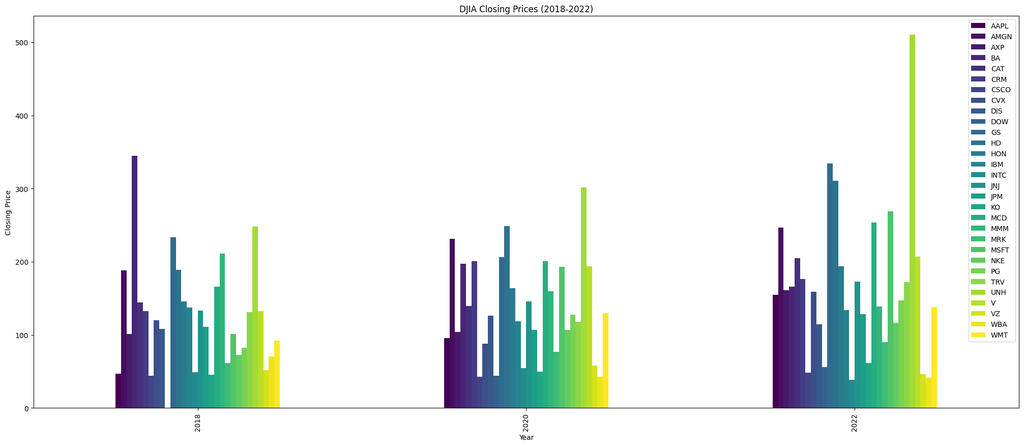

```python
#Choosing all closing prices of each year from columns named 'close'
close = data2.xs('Close', level=1, axis=1)

# Grouping by average closing price per year for each company
closeMean = close.groupby(close.index.year).mean()

# Creating a color map with unique colors
colors = plt.cm.viridis(np.linspace(0, 1, len(close.columns)))

# Plotting the average closing price for each company in the form of a bar chart
closeMean.plot(kind='bar', figsize=(25, 10), color=colors)


# Adding necessary labels for plot.
plt.xlabel('Year')
plt.ylabel('Closing Price')
plt.title('DJIA Closing Prices (2018-2022)')
plt.show()

## DOW Inc became a company in 2019, thats why the 2018 section does not have a bar.
```

**2E. Pie chart for the 11 sectors that make up the stock market**

For the code in this part, we hardcode the values of each sector and use matplot library to show a pie chart. We have to hardcode the values for this as the percentages of the industry and grouping vary by website and since it is just 11 numbers, it is hard to find a dataset just with the values of the proportion of each sector accurately represented.

The stock market can be a complex concept for novice investors. However, it is important to understand the idea of stock sectors. Stock sectors refer to a group of publicly-traded companies that operate within the same general field of business, such as healthcare, energy, or real estate. These companies share similar characteristics, and understanding the different sectors can help investors diversify their portfolios and gain insights into how the market is categorized and can even help and guide new investors on which market/industry to invest in based on the returns for the past quarter in each sector.

Currently, the stock market includes 11 sectors, according to the widely used Global Industry Classification Standard (GICS). These sectors include information technology, healthcare, financials, consumer discretionary, consumer staples, energy, materials, industrials, real estate, utilities, and communication services. Each sector is unique, with its own set of challenges and opportunities, and investors can benefit from understanding the strengths and weaknesses of each sector.

Within the Dow Jones Industrial Average, information technology and healthcare are currently the most prominent sectors, making up 28.6% and 15.8% respectively. These sectors have seen significant growth in recent years, driven by advances in technology and an aging population that requires increasing healthcare services. Conversely, energy is currently the least prominent sector in the Dow Jones, making up just 1.5%. This is reflective of the ongoing shift away from traditional fossil fuels and towards renewable energy sources.

It is worth noting that while the stock market sectors can be useful in understanding market trends, they are not foolproof predictors of individual stock performance. Investors must also consider a range of other factors, such as company-specific financials, global economic conditions, and political events. Nonetheless, gaining a deeper understanding of stock market sectors can help investors make informed decisions and build a diversified portfolio that reflects their unique investment goals and risk tolerance.

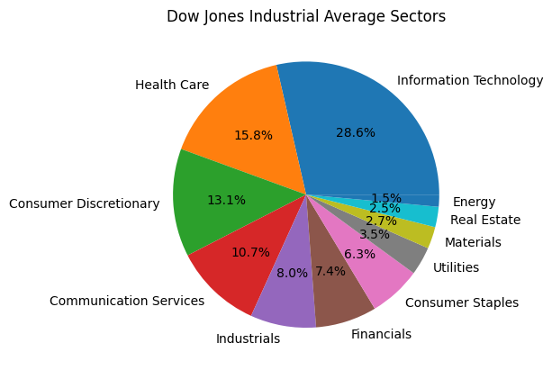

```python
#Pie chart showing sector comp in djia


# Naming sectors and pairing them with percentages that they hold of the Dow Jones
sectors = ['Information Technology', 'Health Care', 'Consumer Discretionary', 'Communication Services', 'Industrials', 'Financials', 'Consumer Staples', 'Utilities', 'Materials', 'Real Estate', 'Energy']
percentages = [27.17, 15.05, 12.46, 10.15, 7.58, 7.06, 6.02, 3.28, 2.52, 2.35, 1.39]


# Plotting a pie chart
plt.pie(percentages, labels=sectors,autopct='%1.1f%%')
# Adding a relevant title
plt.title('Dow Jones Industrial Average Sectors')
plt.show()

## As of August 31, 2020: three companies(Pfizer, Raytheon, Exxon) were replaced for companies (Salesforce.com, Amgen, and Honeywell International)
```

# Part 3: NLP Analysis for Stock Market news from CNBC

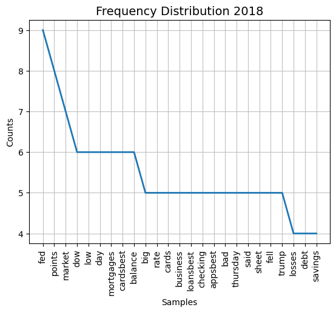

```python
#Here we are importing a url and setting it equal to url2018
url2018 = "https://www.cnbc.com/2018/12/20/us-futures-following-wednesdays-sell-off.html"

#here we are retrieving the content of the url2018
request = requests.get(url2018)

#we are using BeautifulSoup to retrieve the text from html
beau = BeautifulSoup(request.content, 'html.parser')
text = beau.get_text()

#setting the text to lowercase
text = text.lower()
#removing all the punctuation
text = text.translate(str.maketrans('', '', string.punctuation))
#separating the text into individual words
text = nltk.word_tokenize(text)
#making stopwords
stopWords = set(stopwords.words("english"))

#here we are removing words that did not appear in the article but showed up in the data frequency distribution
removeWords = set(["accountsbest", "credit", "personal", "small", "loans"])
#creating a list of words while filtering out certain words such as the removeWords and stopWords
text = list(word for word in text if word.isalpha() and len(word) > 2 and word.casefold() not in stopWords and word.casefold() not in removeWords)
#create a frequency distribution using text
frequencyPlot = FreqDist(text)

#creating a title for the plot, and setting it to font size 14
plt.title('Frequency Distribution 2018', fontsize = 14)

#plotting 25 words
frequencyPlot.plot(25)
```

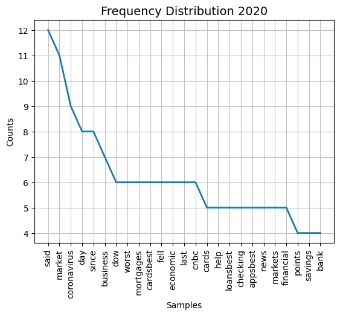

```python
import requests
import nltk
from nltk.corpus import stopwords
from nltk.tokenize import word_tokenize
from nltk.probability import FreqDist
from bs4 import BeautifulSoup
import string
import matplotlib.pyplot as plt

#Here we are importing a url and setting it equal to url2020
url2020 = "https://www.cnbc.com/2020/03/15/traders-await-futures-open-after-fed-cuts-rates-launches-easing-program.html"

#here we are retrieving the content of the url2020
request = requests.get(url2020)

#we are using BeautifulSoup to retrieve the text from html
beau = BeautifulSoup(request.content, 'html.parser')
text = beau.get_text()

#setting the text to lowercase
text = text.lower()
#removing all the punctuation
text = text.translate(str.maketrans('', '', string.punctuation))
#separating the text into individual words
text = nltk.word_tokenize(text)
#making stopwords
stopWords = set(stopwords.words("english"))

#here we are removing words that did not appear in the article but showed up in the data frequency distribution
removeWords = set(["accountsbest", "credit", "personal", "small", "loans"])
#creating a list of words while filtering out certain words such as the removeWords and stopWords
text = list(word for word in text if word.isalpha() and len(word) > 2 and word.casefold() not in stopWords and word.casefold() not in removeWords)
#create a frequency distribution using text
frequencyPlot = FreqDist(text)

#creating a title for the plot, and setting it to font size 14
plt.title('Frequency Distribution 2020', fontsize = 14)

#plotting 25 words
frequencyPlot.plot(25)
```

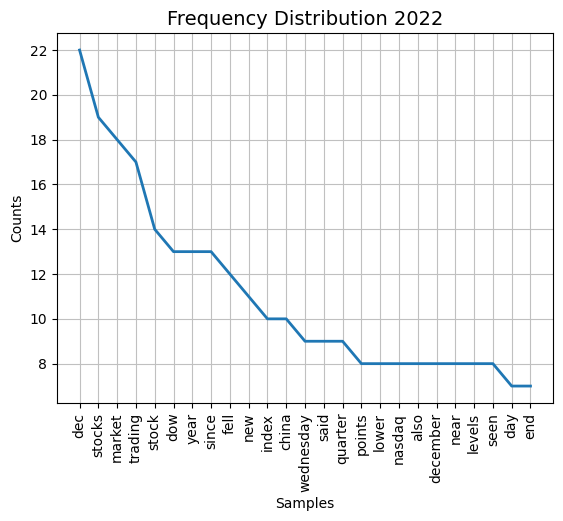

```python
#Here we are importing a url and setting it equal to url2022
url2022 = "https://www.cnbc.com/2022/12/27/stock-market-futures-open-to-close-news.html"

#here we are retrieving the content of the url2022
request = requests.get(url2022)

#we are using BeautifulSoup to retrieve the text from html
beau = BeautifulSoup(request.content, 'html.parser')
text = beau.get_text()

#setting the text to lowercase
text = text.lower()
#removing all the punctuation
text = text.translate(str.maketrans('', '', string.punctuation))
#separating the text into individual words
text = nltk.word_tokenize(text)
#making stopwords
stopWords = set(stopwords.words("english"))

#here we are removing words that did not appear in the article but showed up in the data frequency distribution
removeWords = set(["accountsbest", "credit", "personal", "small", "loans"])
#creating a list of words while filtering out certain words such as the removeWords and stopWords
text = list(word for word in text if word.isalpha() and len(word) > 2 and word.casefold() not in stopWords and word.casefold() not in removeWords)
#create a frequency distribution using text
frequencyPlot = FreqDist(text)

#creating a title for the plot, and setting it to font size 14
plt.title('Frequency Distribution 2022', fontsize = 14)

#plotting 25 words
frequencyPlot.plot(25)
```

When looking at the frequency distributions from 2018, 2020 and 2022 there are several things to take away. We used three articles from CNBC relating to Dow Jones. We wanted to find out what differences there would be in terms of some of the words in the three frequency distributions.

In the 2018 article, the most frequent words were fed, points and market. It is expected that the Fed (Federal Reserve System) would show up frequently in the article as the article is about a fed rate hike that took place. Points is also in the title of the article as it explains how Dow Jones dropped 470 points. Lastly, market is a word that is expected to appear frequently in almost any article that covers stocks such as this one.

In the 2020 article, the most frequent words were said, market and coronavirus. The word said showed up frequently as the article included multiple quotes from people familiar with the stock market. They were mainly quotes centered around their thoughts on how covid will affect the stock market. As in the 2018 article, the word market showed up frequently as the article discussed how the rise of covid had affected the stock market. Lastly, coronavirus is a word that was expected to appear frequently in the article as it was published on March 15, 2020.

When looking at some of the words in the frequency distribution, there are some words that make it more evident when the article was written. One of the words in the 2018 frequency distribution is trump, which makes it more likely that the article was written during Trump’s presidency. One of the words in the 2020 frequency distribution is coronavirus, which makes it obvious that this article was written during or after the coronavirus pandemic. One of the words in the 2022 frequency distribution is december, which makes it more likely that the article was written in the month of december. Some of the words that appeared in the frequency distribution at first weren’t in the article, so we used exclude_words to get rid of those words from the distribution. These words were likely a part of the HTML tags or metadata of the webpage which is why we used exclude_words to filter them out.

# Part 4: API key for Unemployment rates throughout Covid-19 Pandemic

```python
!pip install fredapi
```

```
<bound method NDFrame.head of 1948-01-01    3.4
1948-02-01    3.8
1948-03-01    4.0
1948-04-01    3.9
1948-05-01    3.5
             ...
2022-10-01    3.7
2022-11-01    3.6
2022-12-01    3.5
2023-01-01    3.4
2023-02-01    3.6
Length: 902, dtype: float64>
```

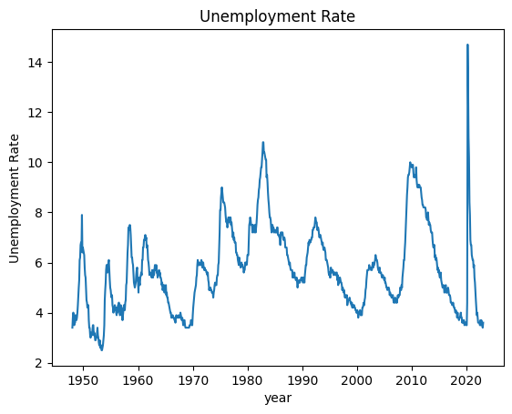

```python
#the following two lines are required for macos only. They add the capacity to check #certificates and verify them.
import ssl
ssl._create_default_https_context = ssl._create_unverified_context

from fredapi import Fred

#get the api key from fred website.
fred = Fred(api_key='4df6af011a2d28b7e0e811da718ed7e0')
#get the unemployment rate from the data for all years.
unemployment = fred.get_series('UNRATE', start_date='2018-01-01', end_date='2022-01-01')
#since the unemployment rates are not given for each day, we get all the data from 1900s to #end date. We get it on annual basis.
print(unemployment.head)


import matplotlib.pyplot as plt
#plotting the unemployment rates for each year
plt.plot(unemployment)
plt.title('Unemployment Rate')
plt.xlabel('year')
plt.ylabel('Unemployment Rate')
#print the plot
plt.show()
#setting parameter of graph to increase graph size to analyze it better.
plt.rcParams["figure.figsize"] = (30,15)
```

The Dow Jones Industrial Average (DJIA) performance can provide valuable insights into the broader economy. The stock prices of the 30 companies included in the DJIA are closely tied to economic conditions and can reflect changes in consumer demand, corporate earnings, and overall economic activity. Significant changes in the DJIA can signal shifts in the labor market and the unemployment rate.

An example of this can be seen in the graphs. in 2020(April), when the United States experienced a sharp increase in unemployment rates due to the COVID-19 pandemic. As businesses shuttered and stay-at-home orders were put in place, the stock market saw significant declines, and the DJIA experienced its largest single-day drop in history. This was indicative of the significant impact the pandemic was having on the economy, with widespread job losses and an acute decline in economic activity. While the correlation between the DJIA and unemployment rates is not perfect, as the stock market can sometimes anticipate changes in economic conditions, the two are closely linked. As the economy slows, the DJIA tends to fall, and this can lead to increased unemployment rates. Similarly, as the economy recovers and the DJIA rebounds, job growth tends to follow.

# Part 6: Conclusion

In conclusion, through data manipulation, visualizations, APIs, and NLP analysis we are clearly able to see that the Covid-19 pandemic severely affected the Dow Jones Industrial Average and in turn the stock market as a whole.

Out of this report, we would like to show that the stock market should not be affected by unforeseen incidents in the world. Yes, the market had a huge dip because of uncertainty, but we are able to see how fast it is able to recover from something as big of a crisis as the Covid-19 pandemic. We hope that in the future, people will see that the market corrects itself so that the economy does not fall drastically in cases such as the pandemic that peaked in 2020.

# References

“Data to Fish.” Data to Fish, https://datatofish.com/bar-chart-python-matplotlib/.

“Data to Fish.” Data to Fish, https://datatofish.com/line-chart-python-matplotlib/.

Foimbert. “Dow Drops Nearly 3,000 Points, as Coronavirus Collapse Continues; Worst Day since '87.” CNBC, CNBC, 16 Mar. 2020, https://www.cnbc.com/2020/03/15/traders-await-futures-open-after-fed-cuts-rates-launches-easing-program.html.

Kolakowski, Mark. “A Brief History of Bear Markets.” Investopedia, Investopedia, 23 Sept. 2022, https://www.investopedia.com/a-history-of-bear-markets-4582652.

Matplotlib Pie Charts, https://www.w3schools.com/python/matplotlib_pie_charts.asp.

Tanayamac. “Dow Closes More than 350 Points Lower in Broad Selloff, Apple Tumbles 3%.” CNBC, CNBC, 28 Dec. 2022, https://www.cnbc.com/2022/12/27/stock-market-futures-open-to-close-news.html.

Tomwfranck. “Dow Drops 470 Points to 14-Month Low in Second Day of Big Losses Following Fed Rate Hike.” CNBC, CNBC, 20 Dec. 2018, https://www.cnbc.com/2018/12/20/us-futures-following-wednesdays-sell-off.html.

“Yfinance.” PyPI, https://pypi.org/project/yfinance/.